# Modeling for Animal Shelter Data

Phil Prosapio, Shayan Khan, Jiyuan Zhou, Bonnie Fan

In this file we have applied four different models (SVM Radial, Multinomial Regression, XGBoost, and Random Forest) to our dataset to predict animal outcomes for the Austin Animal Center. Below we do additional model related cleanup, apply our models to the dataset, and then detail our conclusions and future recommendations and enhancements we gleaned from doing this project.

**Note** that we included certain tags like echo=FALSE and eval=FALSE after we had already trained our models and saved them off to a file. We did this to speed up the file knitting process.

```r
cad_model <- read.csv("Data/Cleaned_Data_Frame.csv") %>%
             select(-X)
```

Prep the data for modeling

```r
cad_model <- cad_model %>%
       select(-DateTime, -MonthYear, -Found.Location, -Breed, -breed_new, -Color)
cad_model <- createDummyFeatures(cad_model,
                                 target = "OutcomeType",
                                 cols = c("S_Organ_Status_In", "Sex", "S_Organ_Status_Out", "AnimalType",
                                          "Intake.Type", "Intake.Condition", "breed_group"))
```

# Handle Dummified Columns

After having dummified the columns, we rename and remove certain columns that would be duplicative or are confusingly named.

```r
cad_model <- cad_model %>%
       select(-AnimalType.Cat) %>%
       dplyr::rename(Is_Dog = AnimalType.Dog)
```

We will be modeling on OutcomeType variable

```r
# Set the number of classes in our classification model
countClasses <- length(unique(cad_model$OutcomeType))
# Train and test split
seed <- 333
inTraining <- createDataPartition(cad_model$OutcomeType, p=0.6, list=FALSE)
training.set <- cad_model[inTraining,]
trainAnimalID <- training.set$AnimalID
training.set <- training.set %>%
  select(-AnimalID)
Totalvalidation.set <- cad_model[-inTraining,]

# This will create another partition of the 40% of the data, so 20%-testing and 20%-validation

inValidation <- createDataPartition(Totalvalidation.set$OutcomeType, p=0.5, list=FALSE)
testing.set <- Totalvalidation.set[inValidation,]
testAnimalID <- testing.set$AnimalID
testing.set <- testing.set %>%
  select(-AnimalID)
validation.set <- Totalvalidation.set[-inValidation,]
validAnimalID <- validation.set$AnimalID
validation.set <- validation.set %>%
  select(-AnimalID)
```

# XGBoost

```r
# Convert classes to integers for xgboost
outcomes <- bind_cols(OutcomeType=c("Adoption", "Died", "Euthanasia",
                                        "Return_to_owner", "Transfer"),
                          Outcome=c(0,1,2,3,4))
# XGBoost requires the classification classes to be encoded as numeric
trainNumeric <- merge(training.set, outcomes, by="OutcomeType", all.x=TRUE, sort=F) %>%
  select(-OutcomeType)
testNumeric <- merge(testing.set, outcomes, by="OutcomeType", all.x=TRUE, sort=F) %>%
  select(-OutcomeType)
trainY <- trainNumeric$Outcome
testY <- testNumeric$Outcome
trainNumeric <- trainNumeric %>%
  select(-Outcome)
testNumeric <- testNumeric %>%
  select(-Outcome)
```

## Now to create the xgboost model

```r
# xgboost-specific design matrices
xgb_train <- xgb.DMatrix(data = as.matrix(trainNumeric),
                         label=as.matrix(trainY), missing=NA)
xgb_test <- xgb.DMatrix(data = as.matrix(testNumeric),
                         label=as.matrix(testY), missing=NA)

params <- list(objective = "multi:softprob", num_class = countClasses, eval_metric = "mlogloss")
```

Calculate # of folds for cross-validation (saved to rds file as it takes some time)

```r
# xgbcv <- xgb.cv(params = params, data = xgb_train, nrounds = 200, nfold = 5, showsd = TRUE,
#                 stratified = TRUE, early_stop_round = 30,
#                 maximize = FALSE, prediction = TRUE)
# save(xgbcv, file="xgb_cv.rda")
load(file="xgb_cv.rda")
# Assign class based on max prob
xgb_train_preds <- data.frame(xgbcv$pred) %>%
  mutate(max = max.col(., ties.method = "last"), label = trainY + 1)
outcomes <- outcomes %>%
  mutate(outcome_nonz = Outcome +1)
xgb_train_preds <- left_join(xgb_train_preds, outcomes, by=c("max" = "outcome_nonz")) %>%
  rename(predOutcome = OutcomeType) %>%
  select(-Outcome)
xgb_train_preds <- left_join(xgb_train_preds, outcomes, by=c("label" = "outcome_nonz")) %>%
  rename(actOutcome = OutcomeType) %>%
  select(-Outcome)
# Generate confusion matrix
confusionMatrix(factor(xgb_train_preds$actOutcome),
                                  factor(xgb_train_preds$predOutcome),
                                  mode = "everything")
```

```
## Confusion Matrix and Statistics
##
##                  Reference
## Prediction        Adoption Died Euthanasia Return_to_owner Transfer
##   Adoption            3816    8         89             666     2339
##   Died                   8    5         20               4       78
##   Euthanasia           163   11        386             135      289
##   Return_to_owner     2654    2         20             353      322
##   Transfer            1580    7        129            2233     1859
##
## Overall Statistics
##
##                Accuracy : 0.3737
##                  95% CI : (0.3665, 0.381)
##     No Information Rate : 0.4786
##     P-Value [Acc > NIR] : 1
##
##                   Kappa : 0.0657
##  Mcnemar's Test P-Value : <2e-16
##
## Statistics by Class:
##
##                      Class: Adoption Class: Died Class: Euthanasia
## Sensitivity                   0.4642   0.1515152           0.59938
## Specificity                   0.6536   0.9935834           0.96383
## Pos Pred Value                0.5516   0.0434783           0.39228
## Neg Pred Value                0.5706   0.9983588           0.98407
## Precision                     0.5516   0.0434783           0.39228
## Recall                        0.4642   0.1515152           0.59938
## F1                            0.5041   0.0675676           0.47420
## Prevalence                    0.4786   0.0019213           0.03749
## Detection Rate                0.2222   0.0002911           0.02247
## Detection Prevalence          0.4028   0.0066954           0.05729
## Balanced Accuracy             0.5589   0.5725493           0.78160
##                      Class: Return_to_owner Class: Transfer
## Sensitivity                         0.10410          0.3804
## Specificity                         0.78252          0.6787
## Pos Pred Value                      0.10534          0.3201
## Neg Pred Value                      0.78025          0.7336
## Precision                           0.10534          0.3201
## Recall                              0.10410          0.3804
## F1                                  0.10472          0.3476
## Prevalence                          0.19743          0.2845
## Detection Rate                      0.02055          0.1082
## Detection Prevalence                0.19510          0.3381
## Balanced Accuracy                   0.44331          0.5295
```

Evaluate number of rounds for xgboost.

```r
min_logloss <- min(xgbcv$evaluation_log[, test_mlogloss_mean])
min_logloss_index = which.min(xgbcv$evaluation_log[, test_mlogloss_mean])
print(min_logloss_index)
```

```
## [1] 29
```

The nrounds for our model should be 29

```r
xgb_model <- xgb.train(params = params, data = xgb_train, nrounds = 29)

# Predict for test set
xgb_test_preds <- predict(xgb_model, newdata = xgb_test)

xgb_test_out <- matrix(xgb_test_preds, nrow = 5, ncol = length(xgb_test_preds) / 5) %>%
               t() %>%
               data.frame() %>%
               mutate(max = max.col(., ties.method = "last"), label = testY + 1)
xgb_test_out <- left_join(xgb_test_out, outcomes, by=c("max" = "outcome_nonz")) %>%
  rename(predOutcome = OutcomeType) %>%
  select(-Outcome)
xgb_test_out <- left_join(xgb_test_out, outcomes, by=c("label" = "outcome_nonz")) %>%
  rename(actOutcome = OutcomeType) %>%
  select(-Outcome)
# Confustion Matrix
xgb_conf <- confusionMatrix(factor(xgb_test_out$actOutcome),
                                  factor(xgb_test_out$predOutcome),
                                  mode = "everything")
xgb_conf
```

```
## Confusion Matrix and Statistics
##
##                  Reference
## Prediction        Adoption Died Euthanasia Return_to_owner Transfer
##   Adoption            1917    0          8             246      135
##   Died                   5    1         12               1       19
##   Euthanasia            56    2        121              55       94
##   Return_to_owner      293    1         15             728       80
##   Transfer             540    0         28             170     1198
##
## Overall Statistics
##
##                Accuracy : 0.6926
##                  95% CI : (0.6804, 0.7045)
##     No Information Rate : 0.491
##     P-Value [Acc > NIR] : < 2.2e-16
##
##                   Kappa : 0.5407
##  Mcnemar's Test P-Value : < 2.2e-16
##
## Statistics by Class:
##
##                      Class: Adoption Class: Died Class: Euthanasia
## Sensitivity                   0.6820   0.2500000           0.65761
## Specificity                   0.8665   0.9935326           0.96264
## Pos Pred Value                0.8313   0.0263158           0.36890
## Neg Pred Value                0.7385   0.9994725           0.98833
## Precision                     0.8313   0.0263158           0.36890
## Recall                        0.6820   0.2500000           0.65761
## F1                            0.7493   0.0476190           0.47266
## Prevalence                    0.4910   0.0006987           0.03214
## Detection Rate                0.3348   0.0001747           0.02114
## Detection Prevalence          0.4028   0.0066376           0.05729
## Balanced Accuracy             0.7742   0.6217663           0.81013
##                      Class: Return_to_owner Class: Transfer
## Sensitivity                          0.6067          0.7851
## Specificity                          0.9140          0.8242
## Pos Pred Value                       0.6517          0.6188
## Neg Pred Value                       0.8976          0.9134
## Precision                            0.6517          0.6188
## Recall                               0.6067          0.7851
## F1                                   0.6284          0.6921
## Prevalence                           0.2096          0.2666
## Detection Rate                       0.1272          0.2093
## Detection Prevalence                 0.1951          0.3382
## Balanced Accuracy                    0.7603          0.8047
```

Looks like overal accuracy hovers at 69.3%. We will note that the other Kaggle teams achieved at maximum 79% accuracy without including the outcome date variable, which qualifies as data leakage.

We can visualize our confusion matrix below

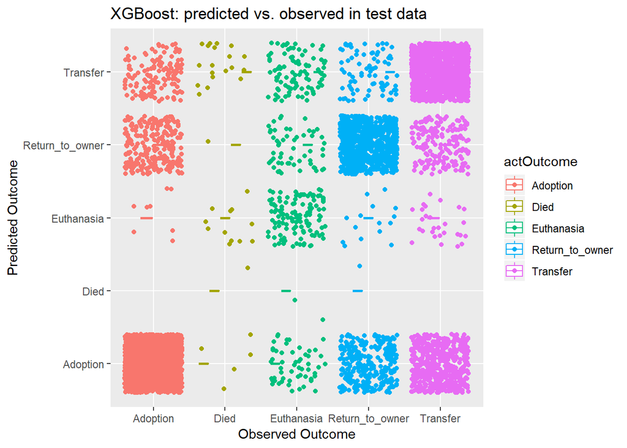

```r
qplot(actOutcome, predOutcome, data=xgb_test_out,  colour= actOutcome,
      geom = c("boxplot", "jitter"),
      main = "XGBoost: predicted vs. observed in test data",
      xlab = "Observed Outcome",
      ylab = "Predicted Outcome")
```

### Feature Importance

We can also get feature importance from xgboost

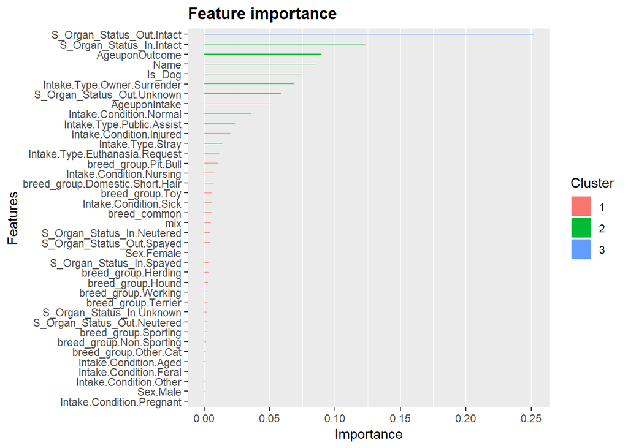

```r
# compute feature importance matrix
xgb_imp = xgb.importance(feature_names = setdiff(names(trainNumeric),"OutcomeType"), model = xgb_model)
xgb.ggplot.importance(xgb_imp)
```

# Multivariate Logistic Model

```r
multinomModel <- multinom(OutcomeType ~ ., data = training.set)
confusionMatrix(as.factor(training.set$OutcomeType),
                as.factor(predict(multinomModel, training.set)), mode = "everything")
```

```
## Confusion Matrix and Statistics
##
##                  Reference
## Prediction        Adoption Died Euthanasia Return_to_owner Transfer
##   Adoption            5857    0         16             763      282
##   Died                  10    0         15               7       83
##   Euthanasia           178    0        301             113      392
##   Return_to_owner      943    0         35            2067      306
##   Transfer            1813    0        122             417     3456
##
## Overall Statistics
##
##                Accuracy : 0.6801
##                  95% CI : (0.673, 0.6871)
##     No Information Rate : 0.5124
##     P-Value [Acc > NIR] : < 2.2e-16
##
##                   Kappa : 0.5188
##  Mcnemar's Test P-Value : < 2.2e-16
##
## Statistics by Class:
##
##                      Class: Adoption Class: Died Class: Euthanasia
## Sensitivity                   0.6655          NA           0.61554
## Specificity                   0.8733    0.993305           0.95907
## Pos Pred Value                0.8466          NA           0.30589
## Neg Pred Value                0.7130          NA           0.98839
## Precision                     0.8466    0.000000           0.30589
## Recall                        0.6655          NA           0.61554
## F1                            0.7452          NA           0.40869
## Prevalence                    0.5124    0.000000           0.02847
## Detection Rate                0.3410    0.000000           0.01752
## Detection Prevalence          0.4028    0.006695           0.05729
## Balanced Accuracy             0.7694          NA           0.78731
##                      Class: Return_to_owner Class: Transfer
## Sensitivity                          0.6139          0.7648
## Specificity                          0.9070          0.8142
## Pos Pred Value                       0.6168          0.5950
## Neg Pred Value                       0.9060          0.9065
## Precision                            0.6168          0.5950
## Recall                               0.6139          0.7648
## F1                                   0.6154          0.6693
## Prevalence                           0.1960          0.2631
## Detection Rate                       0.1203          0.2012
## Detection Prevalence                 0.1951          0.3381
## Balanced Accuracy                    0.7605          0.7895
```

Confusion matrix on test set results

```r
multiPredProb <- predict(multinomModel, testing.set, type = "prob")
multiPred <- predict(multinomModel, testing.set)
multiNomOut_conf <- confusionMatrix(testing.set$OutcomeType, multiPred, mode = "everything")
multiNomOut_conf
```

```
## Confusion Matrix and Statistics
##
##                  Reference
## Prediction        Adoption Died Euthanasia Return_to_owner Transfer
##   Adoption            1960    0         11             246       89
##   Died                   3    0          8               1       26
##   Euthanasia            67    0         92              47      122
##   Return_to_owner      334    0         17             667       99
##   Transfer             620    0         47             139     1130
##
## Overall Statistics
##
##                Accuracy : 0.6723
##                  95% CI : (0.66, 0.6845)
##     No Information Rate : 0.5212
##     P-Value [Acc > NIR] : < 2.2e-16
##
##                   Kappa : 0.5067
##  Mcnemar's Test P-Value : < 2.2e-16
##
## Statistics by Class:
##
##                      Class: Adoption Class: Died Class: Euthanasia
## Sensitivity                   0.6568          NA           0.52571
## Specificity                   0.8738    0.993362           0.95748
## Pos Pred Value                0.8500          NA           0.28049
## Neg Pred Value                0.7005          NA           0.98462
## Precision                     0.8500    0.000000           0.28049
## Recall                        0.6568          NA           0.52571
## F1                            0.7410          NA           0.36581
## Prevalence                    0.5212    0.000000           0.03057
## Detection Rate                0.3424    0.000000           0.01607
## Detection Prevalence          0.4028    0.006638           0.05729
## Balanced Accuracy             0.7653          NA           0.74160
##                      Class: Return_to_owner Class: Transfer
## Sensitivity                          0.6064          0.7708
## Specificity                          0.9027          0.8108
## Pos Pred Value                       0.5971          0.5837
## Neg Pred Value                       0.9060          0.9113
## Precision                            0.5971          0.5837
## Recall                               0.6064          0.7708
## F1                                   0.6017          0.6643
## Prevalence                           0.1921          0.2561
## Detection Rate                       0.1165          0.1974
## Detection Prevalence                 0.1951          0.3382
## Balanced Accuracy                    0.7545          0.7908
```

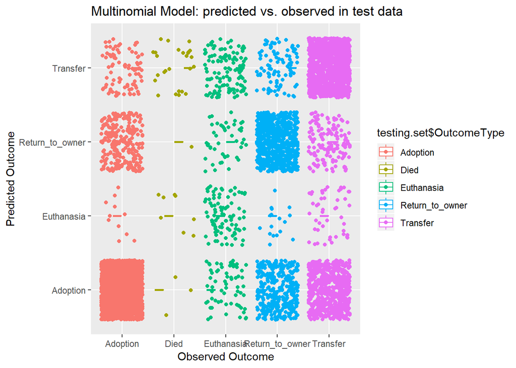

```r
qplot(testing.set$OutcomeType, multiPred, colour=testing.set$OutcomeType,
      geom = c("boxplot", "jitter"),
      main = "Multinomial Model: predicted vs. observed in test data",
      xlab = "Observed Outcome",
      ylab = "Predicted Outcome")
```

We see that the “Died” class is missing from the predicted outcome y axis in the matrix. It looks like many of the actual “Died” class were classified as “Transfer”.

# SVM Radial Model

Next, we’ll explore a Support Vector Machine (SVM) machine learning model. This is a common algorithm for classification problems.

```r
svm_Radial <- caret::train(OutcomeType ~.,
                    data = training.set,
                    method = "svmRadial",
                    preProcess = c("center", "scale"),
                    tuneLength = 10)

svmModel <- predict(svm_Radial, newdata=testing.set)
svmConfusion <- confusionMatrix(data=svmModel, testing.set$OutcomeType)
save(svm_Radial, svmModel, svmConfusion, file = "svmModel.rda")
```

```r
load(file = "svmModel.rda")
svmConfusion
```

```
## Confusion Matrix and Statistics
##
##                  Reference
## Prediction        Adoption Died Euthanasia Return_to_owner Transfer
##   Adoption            1939    2         56             273      579
##   Died                   0    0          0               0        0
##   Euthanasia             3    7        114               3       27
##   Return_to_owner      282    5         51             752      201
##   Transfer              82   24        107              89     1129
##
## Overall Statistics
##
##                Accuracy : 0.6872
##                  95% CI : (0.675, 0.6992)
##     No Information Rate : 0.4028
##     P-Value [Acc > NIR] : < 2.2e-16
##
##                   Kappa : 0.5327
##  Mcnemar's Test P-Value : < 2.2e-16
##
## Statistics by Class:
##
##                      Class: Adoption Class: Died Class: Euthanasia
## Sensitivity                   0.8408    0.000000           0.34756
## Specificity                   0.7338    1.000000           0.99259
## Pos Pred Value                0.6806         NaN           0.74026
## Neg Pred Value                0.8724    0.993362           0.96159
## Prevalence                    0.4028    0.006638           0.05729
## Detection Rate                0.3387    0.000000           0.01991
## Detection Prevalence          0.4976    0.000000           0.02690
## Balanced Accuracy             0.7873    0.500000           0.67007
##                      Class: Return_to_owner Class: Transfer
## Sensitivity                          0.6732          0.5832
## Specificity                          0.8830          0.9203
## Pos Pred Value                       0.5825          0.7890
## Neg Pred Value                       0.9177          0.8121
## Prevalence                           0.1951          0.3382
## Detection Rate                       0.1314          0.1972
## Detection Prevalence                 0.2255          0.2500
## Balanced Accuracy                    0.7781          0.7517
```

Here we can see that we’re getting an accuracy of 69 percent. This is still better than chance, but we’ll see if we can achieve higher accuracy.

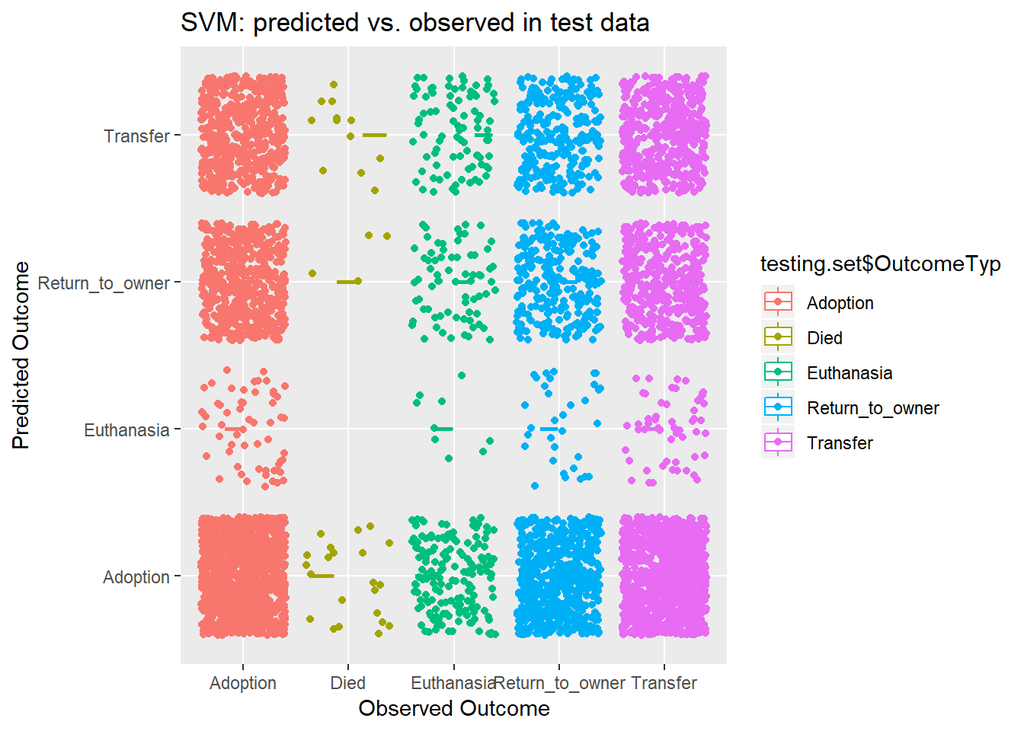

```r
qplot(testing.set$OutcomeType, svmModel,  colour= testing.set$OutcomeTyp,
      geom = c("boxplot", "jitter"),
      main = "SVM: predicted vs. observed in test data",
      xlab = "Observed Outcome",
      ylab = "Predicted Outcome")
```

# Random Forest Model

The reason we chose Random Forest as one of our models is due to a couple of the important features that are a part of the Random Forest model. The ones we were interested were:

- It’s ability to easily handle large number of input variables without variable deletion.
- It runs efficiently on large datasets (ours is not super massive, but it is bigger than what we dealt with in class).
- It generates an internal unbiased estimate of the generalization error as the forest building progresses.

We initially trained our Random Forest model with default or auto-tune parameters.

```r
rf_fit <- train(OutcomeType ~ .,
                data = training.set,
                method = "rf",
                metric = "Accuracy",
                preProcess = c("center", "scale"),
                tuneLength = 10)
save(rf_fit, file="rf_initial_fit.rda")
```

```r
load(file="rf_initial_fit.rda")
rf_pred <- predict(rf_fit, newdata=testing.set)

confusionMatrix(data=rf_pred, testing.set$OutcomeType)
```

```
## Confusion Matrix and Statistics
##
##                  Reference
## Prediction        Adoption Died Euthanasia Return_to_owner Transfer
##   Adoption            1987    4         62             298      560
##   Died                   0    1          0               0        0
##   Euthanasia             6   11        118               4       17
##   Return_to_owner      227    1         49             743      143
##   Transfer              86   21         99              72     1216
##
## Overall Statistics
##
##                Accuracy : 0.71
##                  95% CI : (0.6981, 0.7218)
##     No Information Rate : 0.4028
##     P-Value [Acc > NIR] : < 2.2e-16
##
##                   Kappa : 0.5645
##  Mcnemar's Test P-Value : < 2.2e-16
##
## Statistics by Class:
##
##                      Class: Adoption Class: Died Class: Euthanasia
## Sensitivity                   0.8617   0.0263158           0.35976
## Specificity                   0.7297   1.0000000           0.99296
## Pos Pred Value                0.6826   1.0000000           0.75641
## Neg Pred Value                0.8866   0.9935360           0.96229
## Prevalence                    0.4028   0.0066376           0.05729
## Detection Rate                0.3471   0.0001747           0.02061
## Detection Prevalence          0.5085   0.0001747           0.02725
## Balanced Accuracy             0.7957   0.5131579           0.67636
##                      Class: Return_to_owner Class: Transfer
## Sensitivity                          0.6652          0.6281
## Specificity                          0.9089          0.9266
## Pos Pred Value                       0.6389          0.8139
## Neg Pred Value                       0.9180          0.8298
## Prevalence                           0.1951          0.3382
## Detection Rate                       0.1298          0.2124
## Detection Prevalence                 0.2031          0.2610
## Balanced Accuracy                    0.7870          0.7774
```